# Homework Machine Learning

Ana Monreal Ibero

3 de noviembre de 2016

## Preparation of the data

I load all the libraries that I will use:

```r
library(caret)
```

```r
library(corrplot) # Nice library to do corrlation plots
# This is a library that allows you to do PCA analysis.
# I found it here
# http://www.sthda.com/english/wiki/principal-component-analysis-how-to-reveal-the-most-important-variables-in-your-data-r-software-and-data-mining
library("FactoMineR")
library(factoextra)
```

I read my data

```r
mydir <- "/Users/ami/Dropbox/Coursera/MachineLearning/Tarea"
setwd(mydir)
### Initialize the url and file variables
myurltraining <- "https://d396qusza40orc.cloudfront.net/predmachlearn/pml-training.csv"
myurltesting <- "https://d396qusza40orc.cloudfront.net/predmachlearn/pml-testing.csv"
myfiletesting <- "pml-testing.csv"
myfiletraining <- "pml-training.csv"

# Download the files
if (!file.exists(myfiletraining)) {
    download.file(myurltraining, destfile=myfiletraining)
}
if (!file.exists(myfiletesting)) {
    download.file(myurltesting, destfile=myfiletesting)
}

# Reading the files
training <- read.csv(myfiletraining, header=TRUE, sep=",",
                     na.strings = c("NA",""))
testing <- read.csv(myfiletesting, header=TRUE, sep=",",
                    na.strings = c("NA",""))

# First visual
str(training)
```

```
## 'data.frame':    19622 obs. of  160 variables:
##  $ X                       : int  1 2 3 4 5 6 7 8 9 10 ...
##  $ user_name               : Factor w/ 6 levels "adelmo","carlitos",..: 2 2 2 2 2 2 2 2 2 2 ...
##  $ raw_timestamp_part_1    : int  1323084231 1323084231 1323084231 1323084232 1323084232 1323084232 1323084232 1323084232 1323084232 1323084232 ...
##  $ raw_timestamp_part_2    : int  788290 808298 820366 120339 196328 304277 368296 440390 484323 484434 ...
##  $ cvtd_timestamp          : Factor w/ 20 levels "02/12/2011 13:32",..: 9 9 9 9 9 9 9 9 9 9 ...
##  $ new_window              : Factor w/ 2 levels "no","yes": 1 1 1 1 1 1 1 1 1 1 ...
##  $ num_window              : int  11 11 11 12 12 12 12 12 12 12 ...
##  $ roll_belt               : num  1.41 1.41 1.42 1.48 1.48 1.45 1.42 1.42 1.43 1.45 ...
##  $ pitch_belt              : num  8.07 8.07 8.07 8.05 8.07 8.06 8.09 8.13 8.16 8.17 ...
##  $ yaw_belt                : num  -94.4 -94.4 -94.4 -94.4 -94.4 -94.4 -94.4 -94.4 -94.4 -94.4 ...
##  $ total_accel_belt        : int  3 3 3 3 3 3 3 3 3 3 ...
##  $ kurtosis_roll_belt      : Factor w/ 396 levels "-0.016850","-0.021024",..: NA NA NA NA NA NA NA NA NA NA ...
##  $ kurtosis_picth_belt     : Factor w/ 316 levels "-0.021887","-0.060755",..: NA NA NA NA NA NA NA NA NA NA ...
##  $ kurtosis_yaw_belt       : Factor w/ 1 level "#DIV/0!": NA NA NA NA NA NA NA NA NA NA ...
```

[output cut: 86 more lines]

```r
dim(training) ; dim(testing)
```

```
## [1] 19622   160
```

```
## [1]  20 160
```

I see and decide: * Apparently, many columns many NA, I will quantify that and eliminate those that has mostly NA. * The 5 first columns seem not interesting for what we are doing here. I eliminate those. * I eliminate those with near zero variance. * Finally, because we have that many data, I separate my training data, so I can frabricate models with the *training.train* and test them with the *testing.train* data. * My favorite model will then be applied to the *testing* data.

```r
# There are many columns with NA that I will try to eliminate

# Eliminate columns that in the training set are full of NA
# those which are factors with 1 level
na_count <-sapply(training, function(y) sum(length(which(is.na(y))))/length(y))
quasiempty <- names(na_count[na_count > 0.9])
training <- training[, na_count < 0.9]
testing <- testing[, na_count < 0.9]

# We see if there are near zero variance predictors
zero.var <- nearZeroVar(training, saveMetrics=TRUE)
print(names(training)[zero.var$nzv])
```

```
## [1] "new_window"
```

```r
# Only "new_window"
zero.var.index <- nearZeroVar(training, saveMetrics=FALSE)
training <- training[, -zero.var.index]
testing <- testing[, -zero.var.index]

# X seems the index
# user_name is a string
# cols 3:5 are dates. We do not consider for the moment
# But they might be necessary later on, if there is a tendency with time!
training <- training[, -c(1,2,3,4,5)]
testing <- testing[, -c(1,2,3,4,5)]

# We keep our testing for the end for validation.
# We separate our training in training and testing
set.seed(12345)
inTrain <- createDataPartition(y=training$classe, p=0.6, list=FALSE)
training.train <- training[inTrain,]
testing.train <- training[-inTrain,]
```

There is still plenty of variables. I do a bit of exploration to see if they are correlated.

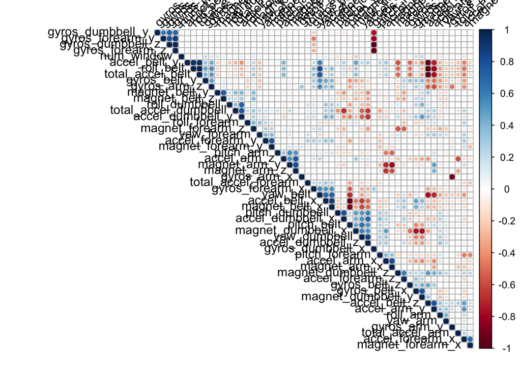

```r
# We explore the matrix of selfcorrelation
M <- abs(cor(training.train[,1:53]))
corrplot(cor(training.train[,1:53]), type="upper", order="hclust", tl.col="black", tl.srt=45)
```

```r
diag(M) <-0
highcorr <- which(M>0.8, arr.ind=T)
print(length(highcorr))
```

```
## [1] 76
```

To do show, I do PCA analysis and I take the predictors that contribute the most to the first PCAs. I am not sure if it is the best option…

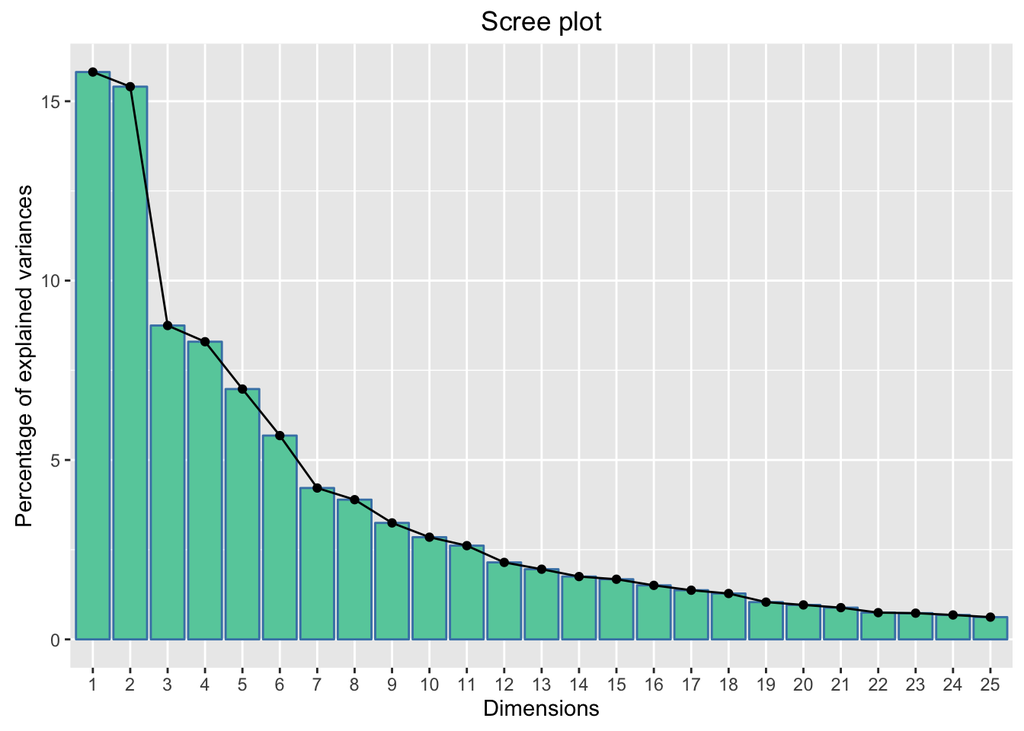

```r
mypca <- PCA(training.train[,1:53], graph = FALSE)
eigenvalues <- mypca$eig
fviz_screeplot(mypca, choice=c("variance"), ncp=25,
               barfill="aquamarine3")
```

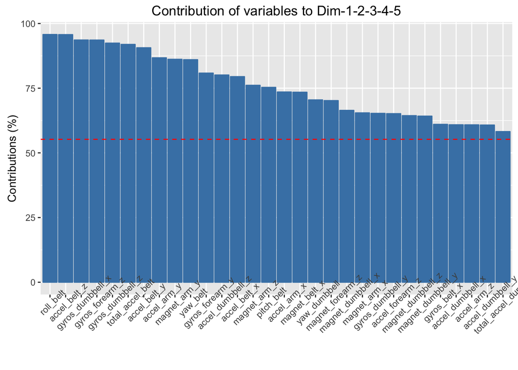

```r
fviz_pca_contrib(mypca, choice = "var", axes = 1:5, top =30)
```

```r
mysel <- c("roll_belt","accel_belt_z","gyros_dumbbell_x", "gyros_forearm_z",
           "gyros_dumbbell_z", "total_accel_belt", "accel_arm_y","magnet_arm_y",
           "yaw_belt", "gyros_forearm_y", "accel_dumbbell_z", "accel_belt_x",
           "magnet_arm_z", "pitch_belt", "accel_arm_x","magnet_belt_x",
           "yaw_dumbbell","magnet_forearm_z","magnet_dumbbell_x",
           "classe")
```

Finally, I set up some sort of cross validation. I use a K-fold with K=10. Later on, I will run some models with it. However, I also run them without it, and apparently I got similar results. Not sure why.

```r
### 10-fold cross validation
mytraincontrol <- trainControl(method='cv', number=10)
```

### Model creation

```r
# Mod 1: linear discriminant analysis
mod1 <- train(classe ~ ., method="lda", data=training.train,
              trControl=mytraincontrol)
predtrain1 <- predict(mod1, training.train)
confusionMatrix(training.train$classe,predtrain1)$overall["Accuracy"]
```

```
##  Accuracy
## 0.7176461
```

```r
predtest1 <- predict(mod1, testing.train)
confusionMatrix(testing.train$classe,predtest1)$overall["Accuracy"]
```

```
##  Accuracy
## 0.7146317
```

```r
# Accuracy 72%

# Mod 2: Recursive Partitioning and Regression Trees
mod2 <- train(classe ~ ., data=training[,mysel], method="rpart",
              trControl=mytraincontrol)
predtrain2 <- predict(mod2, training.train)
confusionMatrix(training.train$classe,predtrain2)$overall["Accuracy"]
```

```
##  Accuracy
## 0.5402514
```

```r
predtest2 <- predict(mod2, testing.train)
confusionMatrix(testing.train$classe,predtest2)$overall["Accuracy"]
```

```
##  Accuracy
## 0.5360693
```

```r
# Accuracy: 54%

# Mod 3: boosting with trees
mod3<- train(classe ~ ., method='gbm',  data=training[,mysel], verbose=FALSE,
             trControl=mytraincontrol)
predtrain3 <- predict(mod3, training.train)
confusionMatrix(training.train$classe,predtrain3)$overall["Accuracy"]
```

```
## Accuracy
## 0.931301
```

```r
predtest3 <- predict(mod3, testing.train)
confusionMatrix(testing.train$classe,predtest3)$overall["Accuracy"]
```

```
##  Accuracy
## 0.9333418
```

```r
# Accuracy = 93 %

# Mod 4: rf
mod4<- train(classe ~ ., method='rf',  data=training[,mysel], verbose=FALSE,
             trControl=mytraincontrol)
predtrain4 <- predict(mod4, training.train)
confusionMatrix(training.train$classe,predtrain4)$overall["Accuracy"]
```

```
## Accuracy
##        1
```

```r
predtest4 <- predict(mod4, testing.train)
confusionMatrix(testing.train$classe,predtest4)$overall["Accuracy"]
```

```
## Accuracy
##        1
```

```r
# Accuracy = 100% (?)
```

| Number | Model | Accuracy |
| --- | --- | --- |
| 1 | Linear Discriminant Analysis | 72% |
| 2 | Recursive Partitioning and Regression Trees | 54% |
| 3 | Boosting with trees | 93% |
| 4 | Random Forest | 100% |

I find extremely weird that a model gives 100% accuracy for both the training and testing data… Since it is not unlikely that I have done something wrong, because I am learning, I prefer to take model Boosting with trees to predict the outcome of the provided test data. It since it sounds more realistic to me.

```r
predfinal <- predict(mod3, testing)
predfinal
```

```
##  [1] B A B A A E D C A A A C B A E E A B B B
## Levels: A B C D E
```